# Data 612 Graduate Project: Exploration of Armed Conflict Location & Event Database (ACLED)

Stephen Hornbeck

2022-10-28

## 1. Loading the necessary packages

```r
knitr::opts_chunk$set(echo = TRUE)
library(readxl)
library(tidyverse)
library(stringr)
```

### 1.a Importing the Dataset

Here is the [link](https://acleddata.com/) to the data repository:

```r
d<-read_csv("Africa_1997-2022_Oct28.csv")
```

### 1.b: Getting Summary Of Data

```r
is_tibble(d)
```

```
## [1] TRUE
```

```r
dim(d)
```

```
## [1] 298654     29
```

```r
glimpse(d)
```

```
## Rows: 298,654
## Columns: 29
## $ ISO              <dbl> 12, 12, 12, 12, 12, 12, 12, 12, 12, 12, 12, 12, 12, 1…
## $ EVENT_ID_CNTY    <chr> "ALG1", "ALG2", "ALG3", "ALG4", "ALG5", "ALG7", "ALG6…
## $ EVENT_ID_NO_CNTY <dbl> 1, 2, 3, 4, 5, 7, 6, 8, 11, 10, 9, 12, 13, 14, 15, 17…
## $ EVENT_DATE       <chr> "01-January-1997", "02-January-1997", "03-January-199…
## $ YEAR             <dbl> 1997, 1997, 1997, 1997, 1997, 1997, 1997, 1997, 1997,…
## $ TIME_PRECISION   <dbl> 1, 1, 1, 1, 1, 1, 1, 1, 1, 1, 1, 1, 1, 1, 1, 1, 1, 1,…
## $ EVENT_TYPE       <chr> "Violence against civilians", "Violence against civil…
## $ SUB_EVENT_TYPE   <chr> "Attack", "Attack", "Attack", "Attack", "Attack", "At…
## $ ACTOR1           <chr> "GIA: Armed Islamic Group", "GIA: Armed Islamic Group…
## $ ASSOC_ACTOR_1    <chr> NA, NA, NA, NA, NA, NA, NA, NA, NA, NA, NA, NA, NA, N…
## $ INTER1           <dbl> 2, 2, 2, 2, 2, 2, 1, 2, 2, 1, 2, 2, 1, 2, 2, 1, 2, 2,…
## $ ACTOR2           <chr> "Civilians (Algeria)", "Civilians (Algeria)", "Civili…
## $ ASSOC_ACTOR_2    <chr> NA, NA, NA, NA, NA, NA, NA, NA, NA, NA, NA, NA, NA, N…
```

[output cut: 16 more lines]

YEAR: Variable for Year (Numeric)

COUNTRY: Country where event happened (Character)

EVENT_TYPE: Category of event type (Character)

FATALITIES: Number of fatalities (Numeric)

ACTOR1: Belligerent in Event (Character)

NOTES: Additional notes about the event (Character)

## 2: Exploring Number of Events

First we can take a look at how many events are included by country. I want to look at the distribution of this to see if most countries have a similar number of events or if there is a skew.

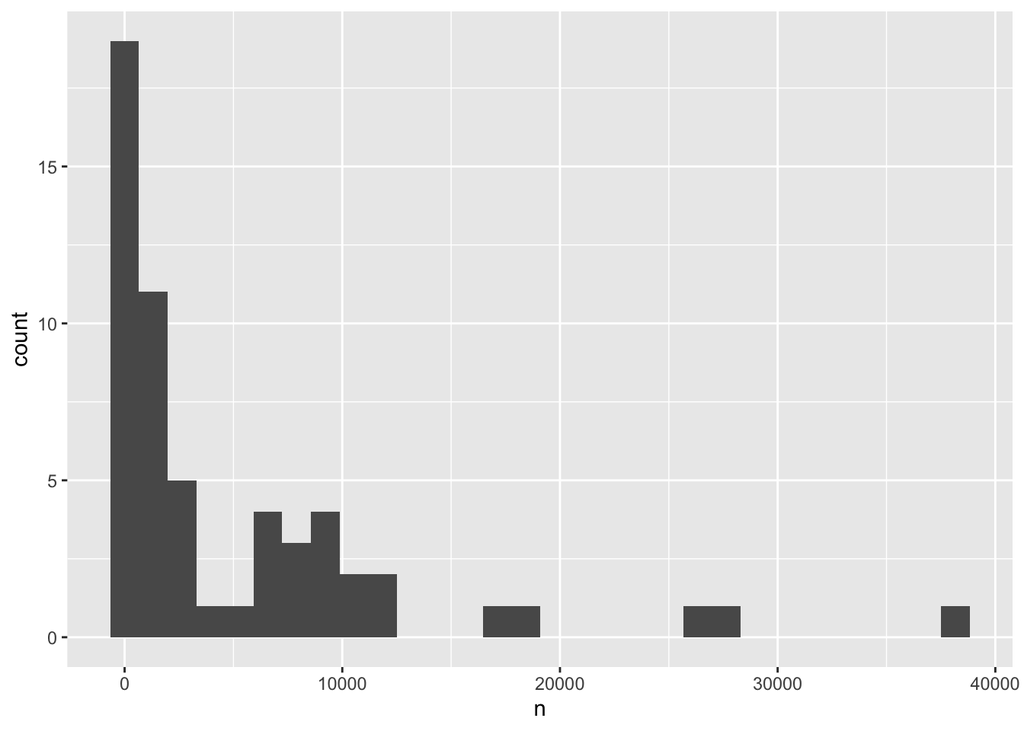

```r
d %>% group_by(COUNTRY) %>% count(.) %>% ggplot(.) + geom_histogram(aes(x=n))
```

The data is very right skewed with most countries having less than 5,000 events in the database and one country having almost 40,000 in the database.

Let’s look at this in terms of trends. How many events are recorded over the different years, is there a trend to how many events are being recorded each year?

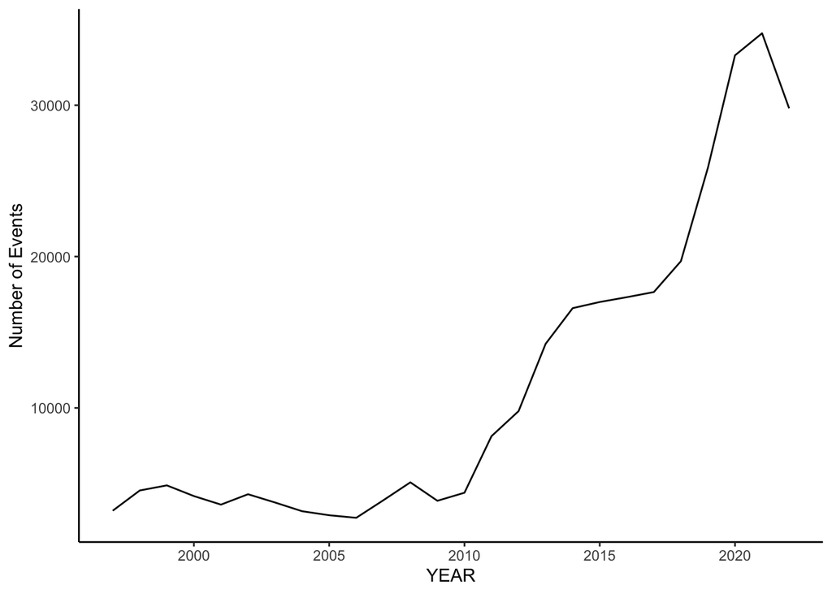

```r
d %>% group_by(YEAR) %>% count(.) %>% ggplot(.) + geom_line(aes(x=YEAR,y=n)) + ylab("Number of Events") +
  theme_classic()
```

Events definitely seem to be increasing over the years. There seems to be a substantive jump after 2010. It would be worth investigating what that jump is from.

But first, we should check to see if maybe this is a collection issue. Let’s look at the number of countries by year to see if the number included in the database has increased over the years.

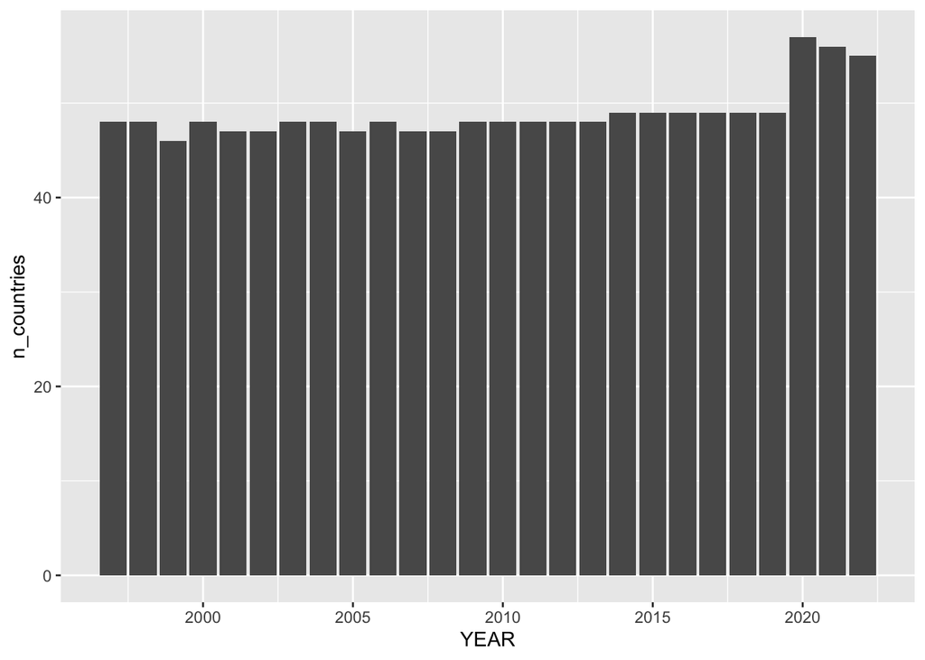

```r
d %>% group_by(YEAR) %>% summarise(n_countries=length(unique(COUNTRY))) %>%
  ggplot(.) + geom_bar(aes(x=YEAR,y=n_countries),stat="identity")
```

*It is not a mechanism, for the most part, of more countries being added in over time. What might be the underlying difference causing the increase over time? Let’s look at the event type, maybe something is happening there*

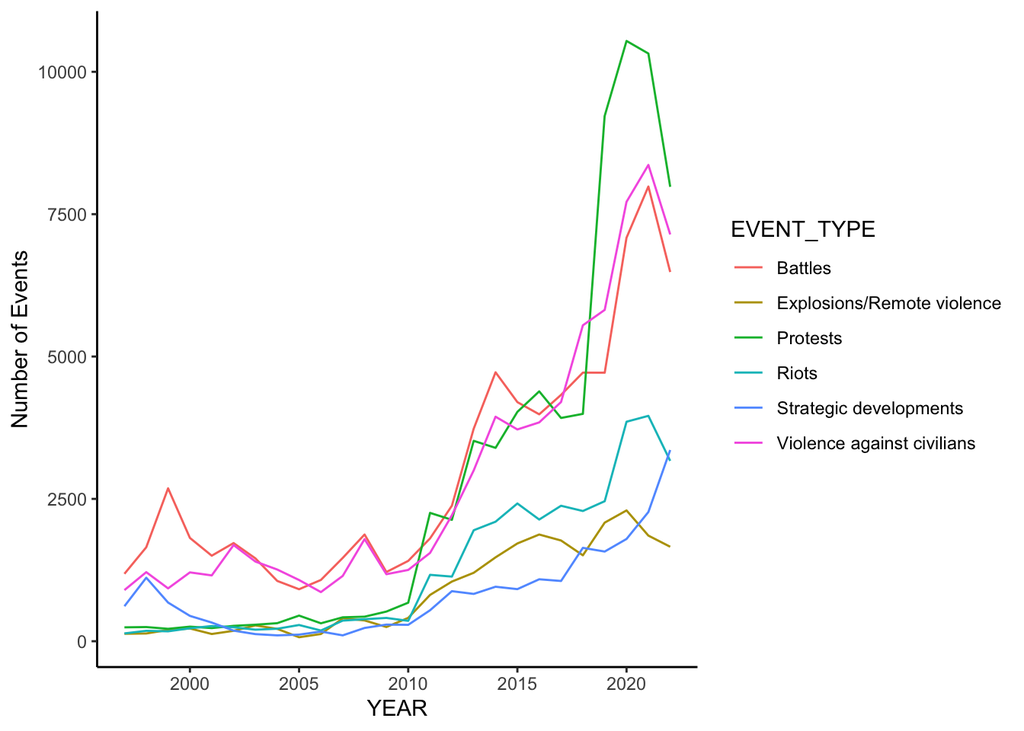

```r
d %>% group_by(YEAR,EVENT_TYPE) %>% count(.) %>% ggplot(.) + geom_line(aes(x=YEAR,y=n,color=EVENT_TYPE)) + ylab("Number of Events") +
  theme_classic()
```

*Alright, so it looks like protests have been dominating the spike as well as battles and violence against civilians*

```r
top_ten<-d %>% filter(EVENT_TYPE %in% c("Protests",
                                                     "Violence against civilians","Battles")) %>% group_by(COUNTRY) %>% count() %>% arrange(desc(n)) %>% ungroup() %>%
  slice(1:10)

top_ten
```

```
## # A tibble: 10 × 2
##    COUNTRY                          n
##    <chr>                        <int>
##  1 Somalia                      27515
##  2 Nigeria                      22766
##  3 Democratic Republic of Congo 21567
##  4 Sudan                        14936
##  5 South Africa                 10405
##  6 Algeria                      10107
##  7 Burundi                       7886
##  8 Ethiopia                      7831
##  9 South Sudan                   7576
## 10 Tunisia                       7448
```

*Lets focus on the top 10 countries here. I am curious to see how things have changed over time and what is driving the events in these different countries*

```r
#
d %>% filter(EVENT_TYPE %in% c("Protests",
                                                     "Violence against civilians","Battles")) %>% filter(COUNTRY %in% top_ten$COUNTRY) %>% group_by(COUNTRY,EVENT_TYPE) %>% count() %>% arrange(desc(n))
```

```
## # A tibble: 30 × 3
## # Groups:   COUNTRY, EVENT_TYPE [30]
##    COUNTRY                      EVENT_TYPE                     n
##    <chr>                        <chr>                      <int>
##  1 Somalia                      Battles                    18293
##  2 Democratic Republic of Congo Battles                    10276
##  3 Nigeria                      Violence against civilians  9341
##  4 South Africa                 Protests                    9138
##  5 Democratic Republic of Congo Violence against civilians  8732
##  6 Algeria                      Protests                    7906
##  7 Somalia                      Violence against civilians  7568
##  8 Nigeria                      Battles                     7282
##  9 Tunisia                      Protests                    6965
## 10 Nigeria                      Protests                    6143
## # … with 20 more rows
```

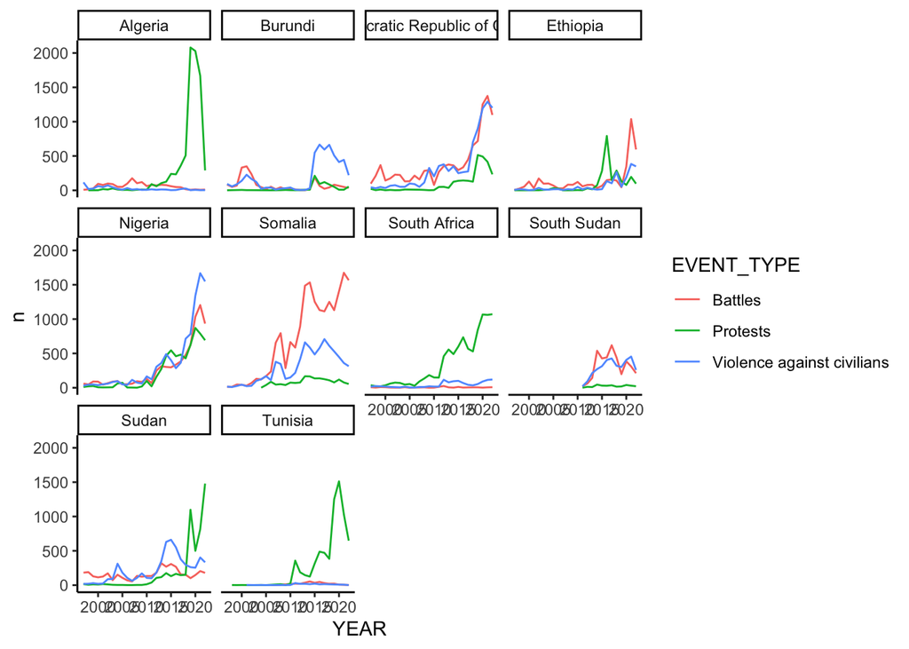

```r
d %>% filter(EVENT_TYPE %in% c("Protests",
                                                     "Violence against civilians","Battles")) %>% filter(COUNTRY %in% top_ten$COUNTRY) %>% group_by(YEAR,COUNTRY,EVENT_TYPE) %>% count() %>% arrange(desc(n)) %>%
  ggplot(.) + geom_line(aes(x=YEAR,y=n,color=EVENT_TYPE)) + facet_wrap(COUNTRY~.) +
  theme_classic()
```

```r
alg<-d %>% filter(COUNTRY=="Algeria")

length(unique(alg$ACTOR1))
```

```
## [1] 77
```

```r
alg<-alg %>% mutate(ACTOR1_new=case_when(str_detect(ACTOR1,"Military*")~"Algerian Military",
                                    str_detect(ACTOR1,"Police*")~"Police",
                                    str_detect(ACTOR1,"Protest*")~"Protestors",
                                    str_detect(ACTOR1,"Riot*")~"Protestors",
                                    str_detect(ACTOR1,"Sala*|Islam*|Milita")~"Militia/Armed Group",
                                TRUE~ACTOR1))

length(unique(alg$ACTOR1_new))
```

```
## [1] 44
```

```r
alg<-alg %>% mutate(ACTOR1_new=forcats::fct_lump(ACTOR1_new,n = 9,other_level = "Other"))

length(unique(alg$ACTOR1_new))
```

```
## [1] 10
```

# Violence by Actor

Looking at the events is interesting but what if we want to look at how these translate into deaths of individuals and who is primarily responsible?

We could first group by the actors and year, sum the fatalities by group, sum the total events, then get a ratio of fatalities to event by group. This would show us what groups were causing the most violence in the countries and would tell us in Algeria whether protests were turning violent.

```r
violence<-alg %>% filter(COUNTRY=="Algeria") %>% group_by(YEAR,ACTOR1_new) %>% dplyr::summarise(count=n(),fatalities=sum(FATALITIES),Fatality_to_Event=fatalities/count)
```

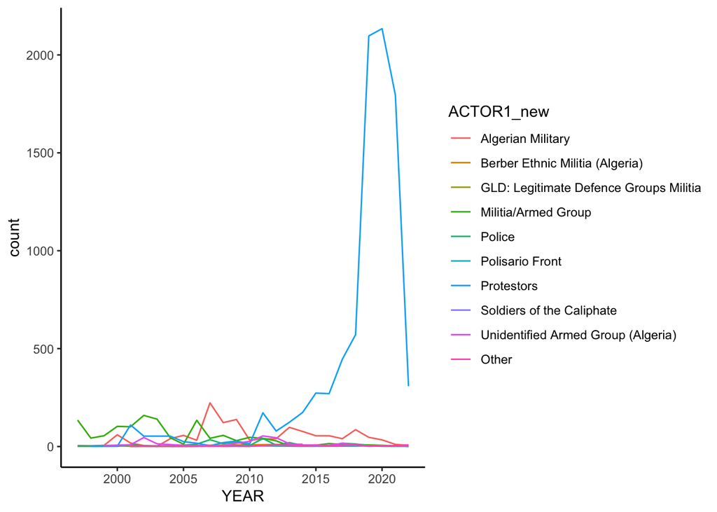

```r
violence %>%  ggplot(.) + geom_line(aes(x=YEAR,y=count,color=ACTOR1_new),stat="identity",position="dodge")+
  theme_classic()
```

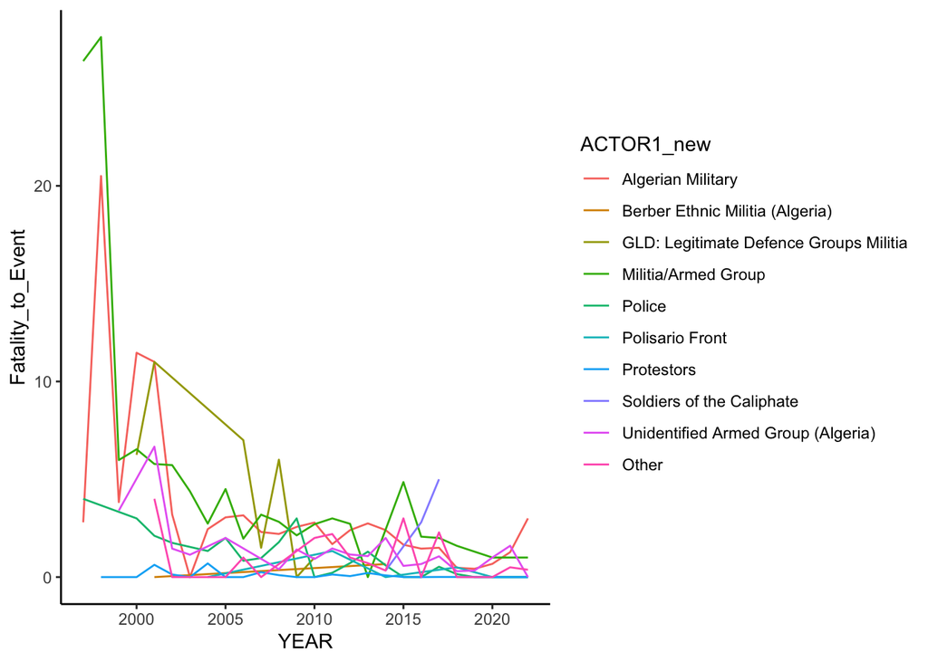

```r
violence%>% ggplot(.) +
  geom_line(aes(x=YEAR,y=Fatality_to_Event,color=ACTOR1_new),stat="identity",position="dodge")+
  theme_classic()
```

So what we can see from this chart is that protests have mostly been non-violence and most events ending in violence come from militias and from the National Army.

So let’s model this data now. I am curious to see how these events correspond to instability and GDP of Algeria. First I am going to summarize the events fatalities by events by year.

```r
violence2<-violence %>% group_by(YEAR,) %>% summarise(count=sum(count),fatalities=sum(fatalities),Fatality_to_Event=fatalities/count)

print(violence2,n=10)
```

```
## # A tibble: 26 × 4
##     YEAR count fatalities Fatality_to_Event
##    <dbl> <int>      <dbl>             <dbl>
##  1  1997   141       3579             25.4
##  2  1998    48       1269             26.4
##  3  1999    66        369              5.59
##  4  2000   170       1389              8.17
##  5  2001   250        945              3.78
##  6  2002   268       1007              3.76
##  7  2003   208        630              3.03
##  8  2004   142        262              1.85
##  9  2005   108        254              2.35
## 10  2006   197        382              1.94
## # … with 16 more rows
```

I then downloaded the World Bank GDP growth rates, gathered the wide data and transformed it to long data and ran a simple linear regression of the results.

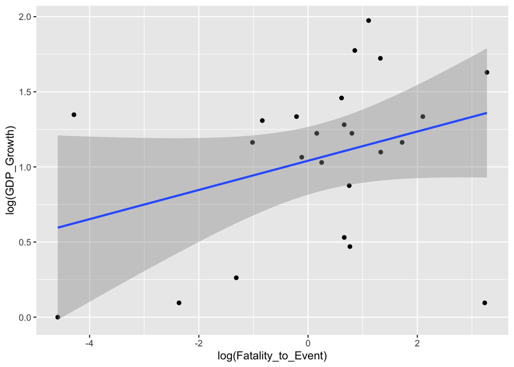

```r
read_csv("API_NY.GDP.MKTP.KD.ZG_DS2_en_csv_v2_4751609.csv") %>% filter(str_detect(`Country Name`,"Algeria")) %>%
  select(-`Country Name`,-`Country Code`,-`Indicator Name`,-`Indicator Code`) %>%
  gather(.,key="YEAR",value="GDP_Growth") %>% mutate(YEAR=as.numeric(YEAR)) %>% left_join(violence2,.,by="YEAR") %>% ggplot(.,aes(y=log(GDP_Growth),x=log(Fatality_to_Event))) + geom_point()+
  geom_smooth(method=lm)
```

This is…unexpected. This model (a log x log model) shows that the higher the fatality per event, the higher the GDP growth. So you would expect times of high violence and instability to lead to more growth. This however requires some country level knowledge and the times of high violence corresponded to economic liberalization efforts and privatizing industries in the 1990s.

## 3. Mapping Results

This dataset is too large and mapping all of the data points will either crash the computer or slow down the analysis to a crawl. One option is to sample the data and present a sample of the data.

This mapping with leaflet also provides options to pop-ups in the points where we can include the notes about the events.

```r
library(leaflet)
newest<-alg %>% filter(YEAR==2019)

small<-newest %>% slice(sample(1:nrow(newest),50))
small %>% leaflet(.) %>% addTiles() %>% addMarkers(lng=~LONGITUDE, lat=~LATITUDE, popup=~NOTES)
```

[interactive chart not shown]

Another alternative is to focus on some key attributes to look at one the map. Here I put only want to look at the number of protests that were attended by “masses” of people

```r
newest %>% filter(str_detect(NOTES,"masses")) %>% leaflet(.) %>% addTiles() %>%
  addMarkers(lng=~LONGITUDE, lat=~LATITUDE, popup=~NOTES)
```

[interactive chart not shown]